# 201.9. MPC_orbits table

For the Rubin Science Platform at data.lsst.cloud.  
Data Release: [Data Preview 2](https://dp2.lsst.io/)  
Container Size: Large  
LSST Science Pipelines version: r30.0.10  
Last verified to run: 2026-08-05  
Repository: github.com/lsst/tutorial-notebooks  
DOI: 10.11578/rubin/dc.20250909.20

**Learning objective:** To understand the contents of the `mpc_orbits` table and how to access it.

**LSST data products:** `mpc_orbits`

**Packages:** `lsst.rsp`

**Credit:** Originally developed by the Rubin Community Science team. Please consider acknowledging them if this notebook is used for the preparation of journal articles, software releases, or other notebooks.

**Get Support:** Everyone is encouraged to ask questions or raise issues in the [Support Category](https://community.lsst.org/c/support) of the Rubin Community Forum. Rubin staff will respond to all questions posted there.

## 1. Introduction

The `mpc_orbits` table contains orbit information from the Minor Planet Center (MPC) for all known Solar System objects (SSOs) as of a given date, including *but not limited to* detections and discoveries made by Rubin. For DP2, this includes known SSOs up to 11 March 2026 (minus those with an arc length over the total number of observations selected for use in orbit fitting by the MPC (`arc_length_sel`) $\leq$ 2 days), a total of 1,505,545 objects.

This table is ingested from the MPC, where Rubin acts as a downstream distributor with many fields in the `mpc_orbits` table originating upstream at the MPC; inconsistencies or missing information in the MPC's `mpc_orbits` table may therefore be present in the DP2 table.

> **Known issues:** Some fields in the `mpc_orbits` table are known to contain inconsistent information. For further information on the `mpc_orbits` table, including known issues, see the [MPC documentation](https://minorplanetcenter.net/mpcops/documentation/mpc-orbits/).
- TAP table name: `dp2.mpc_orbits`
- columns: 53
- rows: 1,505,545

**Related tutorials:** The TAP data access services are demonstrated in the 100-level "How to" tutorials.

### 1.1. Import packages

Import standard python package `matplotlib`.

From the `lsst` package, import the module for the TAP service.

```python
import matplotlib.pyplot as plt
from lsst.rsp import RSPDiscovery
```

### 1.2. Define parameters and functions

Create an instance of the TAP service.

```python
discovery = RSPDiscovery("dp2")
service = discovery.get_tap_client()
```

## 2. Schema (columns)

To browse the table schema visit the [Rubin schema browser](https://sdm-schemas.lsst.io/), or use the TAP service via the Portal Aspect or as demonstrated in Section 2.1.

### 2.1. Retrieve table schema

To retrieve the table schema, define a query for the schema columns of the `mpc_orbits` table and run the query job.

```python
query = "SELECT column_name, datatype, description, unit " \
        "FROM tap_schema.columns " \
        "WHERE table_name = 'dp2.mpc_orbits'"
job = service.submit_job(query)
job.run()
job.wait(phases=['COMPLETED', 'ERROR'])
print('Job phase is', job.phase)
if job.phase == 'ERROR':
    job.raise_if_error()
```

```
Job phase is COMPLETED
```

Retrieve the query results and display them as an `astropy` table with the `to_table()` attribute.

```python
assert job.phase == 'COMPLETED'
results = job.fetch_result().to_table()
results
```

*Table length=53*

| column_name str64 | datatype str64 | description str512 | unit str64 |
| --- | --- | --- | --- |
| id | int | Internal ID (generally not seen/used by the user) |  |
| designation | char | The primary provisional designation in unpacked form (e.g. 2008 AB). |  |
| packed_primary_provisional_designation | char | The primary provisional designation in packed form (e.g. K08A00B) |  |
| unpacked_primary_provisional_designation | char | The primary provisional designation in unpacked form (e.g. 2008 AB) |  |
| mpc_orb_jsonb | char | Details of the orbit solution in JSON form |  |
| created_at | char | When this row was created |  |
| updated_at | char | When this row was updated |  |
| orbit_type_int | int | Orbit Type (Integer) |  |
| u_param | int | U parameter |  |
| ... | ... | ... | ... |
| mean_anomaly_unc | double | Uncertainty on Mean Anomaly [degrees] | deg |
| period_unc | double | Uncertainty on Orbital Period [days] | d |
| mean_motion_unc | double | Uncertainty on Orbital Mean Motion [degrees per day] | deg.d-1 |
| epoch_mjd | double | Epoch of the Orbfit-Solution in MJD | d |
| h | double | H-Magnitude | mag |
| g | double | G-Slope Parameter |  |
| not_normalized_rms | double | unnormalized rms of the fit [arcsec] | arcsec |
| normalized_rms | double | rms of the fit [unitless] |  |
| earth_moid | double | Minimum Orbit Intersection Distance [au] with respect to the Earths Orbit | AU |
| fitting_datetime | char | Date of the last orbit fit |  |

The table displayed above has been truncated.

Option to print every column name as a list.

```python
# for col in results['column_name']:
#     print(col)
```

Delete the job, but not the `results`.

```python
del query
job.delete()
```

### 2.2. Key Columns

Of the 53 columns in the `mpc_orbits` table, several are the most commonly used.

#### 2.2.1. Designation

The primary provisional designation in unpacked form:

- `designation`

The `designation` field can be used to join the `mpc_orbits` table with other DP2 Solar System tables.

#### 2.2.2. Primary provisional designation

The primary provisional designation (unpacked format):

- `unpacked_primary_provisional_designation`

The primary provisional designation (packed format):

- `packed_primary_provisional_designation`

#### 2.2.3. Orbital elements

The osculating orbital elements (distances measured in units of au, angles measured in units of deg):

- `a`, `q`, `e`, `i`, `argperi`, `node`, `mean_anomaly`, `peri_time`

The osculating orbital element uncertainties:

- `a_unc`, `q_unc`, `e_unc`, `i_unc`, `argperi_unc`, `node_unc`, `mean_anomaly_unc`, `peri_time_unc`

#### 2.2.4. Period and mean motion

Orbital period and uncertainty (days):

- `period`, `period_unc`

Mean motion and uncertainty (deg/day):

- `mean_motion`, `mean_motion_unc`

#### 2.2.5. Epoch of orbit fit

Epoch of the orbit fit solution in MJD:

- `epoch_mjd`

#### 2.2.6. Orbit type

Orbit type (integer):

- `orbit_type_int`

For the orbit type definitions, see the [Minor Planet Center](https://www.minorplanetcenter.net/mpcops/documentation/orbit-types/) website. Tutorial 308.1 Orbits in the Solar System science series also discusses the orbit type definitions.

#### 2.2.7. Number of observations

Total number of all observations (optical + radar) available:

- `nobs_total`

Total number of all observations (optical + radar) selected for use in orbit fitting:

- `nobs_total_sel`

#### 2.2.8. G-slope parameter and absolute magnitude

G-slope parameter:

- `g`

Absolute magnitude:

- `h`

#### 2.2.9. Non-gravitational acceleration components

A1 component of the non-gravitational acceleration for comets and uncertainty (10^(-10) au/d^2):

- `a1`, `a1_unc`

A2 component of the non-gravitational acceleration for comets and uncertainty (10^(-10) au/d^2):

- `a2`, `a2_unc`

A3 component of the non-gravitational acceleration for comets and uncertainty (10^(-10) au/d^2):

- `a3`, `a3_unc`

#### 2.2.10. Solar radiation pressure

Solar radiation pressure component and uncertainty:

- `srp`, `srp_unc`

#### 2.2.11. Yarkovsky acceleration

Yarkovsky acceleration component and uncertainty:

- `yarkovsky`, `yarkovsky_unc`

## 3. Data access

The `mpc_orbits` table is only available via the TAP service. It is not available with the butler.

### 3.1. TAP (Table Access Protocol)

The `mpc_orbits` table is stored in Qserv and accessible via the TAP services using ADQL queries.

#### 3.1.1. Catalog size

Retrieve the size of the `mpc_orbits` catalog.

```python
query = "SELECT COUNT(*) "\
        "FROM dp2.mpc_orbits "
job = service.submit_job(query)
job.run()
job.wait(phases=['COMPLETED', 'ERROR'])
print('Job phase is', job.phase)
if job.phase == 'ERROR':
    job.raise_if_error()
```

```
Job phase is COMPLETED
```

Fetch the results as an `astropy` table.

```python
assert job.phase == 'COMPLETED'
results = job.fetch_result().to_table()
print(results)
```

```
 COUNT1
-------
1505545
```

The DP2 `mpc_orbits` table contains orbit information from the MPC for all known SSOs as of 11 March 2026, consisting of 1,505,545 objects in total and *includes but is not limited to* detections and discoveries made by Rubin.

#### 3.1.2. Demo query

To query the full `mpc_orbits` table, remove "TOP 100" from the below query.

```python
query = "SELECT TOP 100 designation, q, e, i "\
        "FROM dp2.mpc_orbits " \
        "ORDER BY designation ASC "
job = service.submit_job(query)
job.run()
job.wait(phases=['COMPLETED', 'ERROR'])
print('Job phase is', job.phase)
if job.phase == 'ERROR':
    job.raise_if_error()
```

```
Job phase is COMPLETED
```

Fetch the results as an `astropy` table and convert to a pandas dataframe.

```python
assert job.phase == 'COMPLETED'
results = job.fetch_result()
result_df = results.to_table().to_pandas()
```

Option to display the results.

```python
# result_df
```

The semimajor axis is included in the `mpc_orbits` table, but many entries are missing, as described in Section 1. For further information on the known issues with the `mpc_orbits` table, see the [MPC documentation](https://minorplanetcenter.net/mpcops/documentation/mpc-orbits/). The semimajor axis ($a$) can be computed from the perihelion distance ($q$) and eccentricity ($e$) using the relationship $a$ = $q$ / (1.0-$e$).

Add a column to `results` with the calculated semimajor axis.

```python
result_df['a_calc'] = result_df['q'] / (1.0-result_df['e'])
```

Plot semimajor axis versus eccentricity and semimajor axis versus inclination for the TOP 100 Solar System objects in the DP2 `mpc_orbits` table.

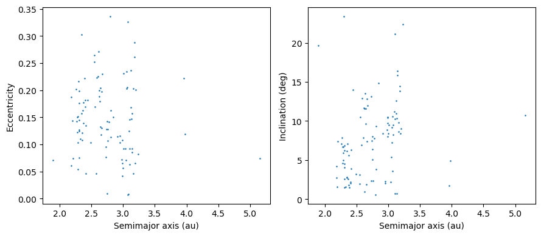

```python
fig, (ax1, ax2) = plt.subplots(1, 2, figsize=(9, 4))

ax1.scatter(result_df['a_calc'], result_df['e'], s=0.75)
ax1.set_xlabel('Semimajor axis (au)')
ax1.set_ylabel('Eccentricity')

ax2.scatter(result_df['a_calc'], result_df['i'], s=0.75)
ax2.set_xlabel('Semimajor axis (au)')
ax2.set_ylabel('Inclination (deg)')

plt.tight_layout()
plt.show()
```

> **Figure 1:** Semimajor axis versus eccentricity (left) and semimajor axis versus inclination (right) for the TOP 100 Solar System objects in the DP2 `mpc_orbits` table.

For more details on the orbital classifications of the DP2 Solar System objects, see tutorial 308.01 Orbits.

```python
job.delete()
del query
```

#### 3.1.3. Joinable tables

The `mpc_orbits` table can be joined to the `SSObject` table on the column `designation`.

The `SSObject` table contains linked Solar System objects (groupings of difference image detections) from Rubin. The DP2 release `SSObject` table contains 299,343 unique Solar System objects detected by Rubin.

The `mpc_orbits` table has many more rows than the `SSObject` table with each `designation` field in the `SSObject` table having a 1:1 corresponding entry in the `mpc_orbits` tables.

The following query joins the `mpc_orbits` and `SSObject` tables. Columns returned include the designation, orbital elements, and the number of observations for the TOP 100 objects in the tables.

```python
query = "SELECT TOP 100 mpc.designation, "\
        "mpc.q, mpc.e, mpc.i, sso.nObs "\
        "FROM dp2.mpc_orbits AS mpc " \
        "JOIN dp2.SSObject AS sso ON mpc.designation = sso.designation"
```

```python
job = service.submit_job(query)
job.run()
job.wait(phases=['COMPLETED', 'ERROR'])
print('Job phase is', job.phase)
if job.phase == 'ERROR':
    job.raise_if_error()
```

```
Job phase is COMPLETED
```

Fetch the results as an `astropy` table and convert to a pandas dataframe.

```python
assert job.phase == 'COMPLETED'
results = job.fetch_result()
result_df = results.to_table().to_pandas()
```

The semimajor axis is included in the `mpc_orbits` table, but many entries are missing, as described in Section 1. For further information on the known issues with the `mpc_orbits` table, see the [MPC documentation](https://minorplanetcenter.net/mpcops/documentation/mpc-orbits/). The semimajor axis ($a$) can be computed from the perihelion distance ($q$) and eccentricity ($e$) using the relationship $a$ = $q$ / (1.0-$e$).

Add a column to `results` with the calculated semimajor axis.

```python
result_df['a_calc'] = result_df['q'] / (1.0-result_df['e'])
```

Option to display the results.

```python
# result_df
```

Plot semimajor axis versus number of observations for the TOP 100 Rubin-detected DP2 Solar System objects.

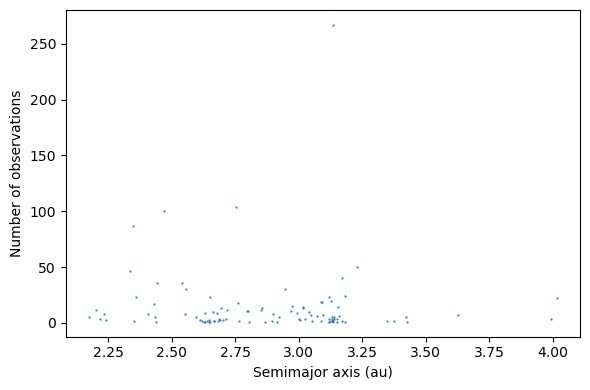

```python
fig, ax = plt.subplots(figsize=(6, 4))

ax.scatter(result_df['a_calc'], result_df['nObs'], s=0.3)
ax.set_xlabel('Semimajor axis (au)')
ax.set_ylabel('Number of observations')

plt.tight_layout()
plt.show()
```

Clean up.

```python
job.delete()
del query, results, result_df
```